# How real is Racing Louisville?: Part 2

Overall, the two teams are pretty even on defense. Louisville is doing better on xG conceded, winning tackles, and not getting dispossessed, but Seattle has still allowed fewer goals. Overall I would say there’s not much to conclude here.

This doesn’t perfectly fit in either offense or defense but I’m just going to squeeze a test for xG differential in here.

*Hypothesis test 11: xG differential*

Null hypothesis: Louisville does not have a higher xG differential than Seattle this season.

Alternative hypothesis: Louisville does have a higher xG differential than Seattle this season.

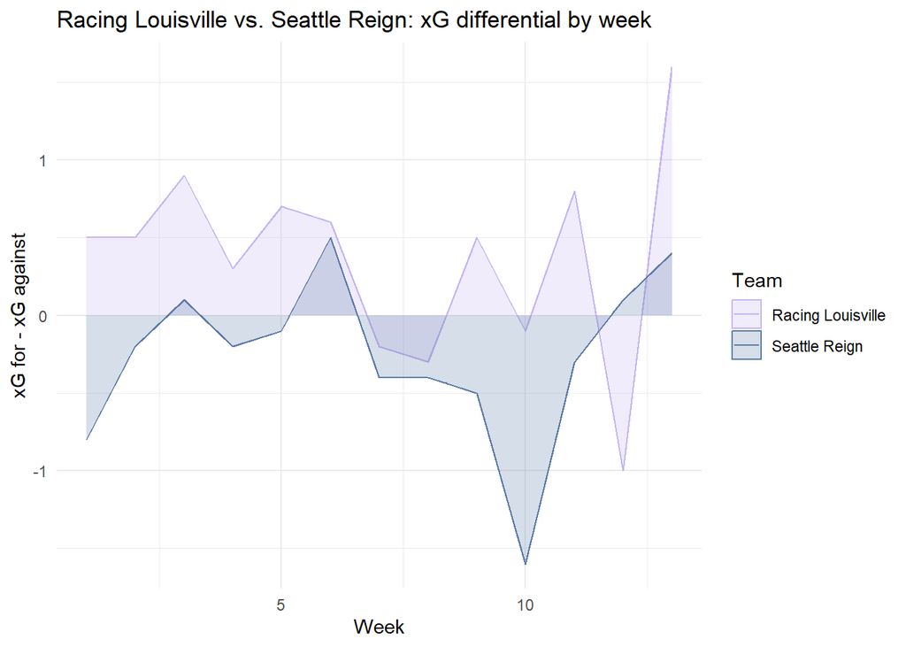

Louisville does seem like they’re doing better.

| Dependent Variable | t | df | p | d | 95% CI |
| --- | --- | --- | --- | --- | --- |
| xG_Differential | 2.69 | 23.21 | .006** | 1.06 | [0.22, 1.87] |

They’re definitely doing better! **Racing Louisville has a higher xG differential than the Seattle Reign this season**.

**Realm 3: Consistency**

This is where the real question is–how consistent is this team, and can we really expect them to keep it up for the rest of the season? Although I’ve been vaguely looking at consistency through line graphs so far, I’m going to now quantify it by performing F-tests that compare the variances of two groups. I will be analyzing goals, goals against, xG, xG against, xG differential, shots for, and shots against.

*Hypothesis test 1: Goals for*

Null hypothesis: There is no difference in the variance between Louisville’s goals scored this season and Seattle’s goals scored this season.

Alternative hypothesis: There is less variance in Louisville’s goals scored this season than Seattle’s.

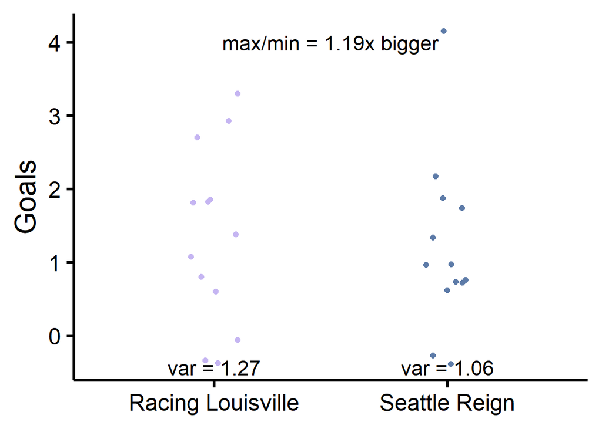

Louisville appears to have more variance–not a great sign.

| F statistic | p-value | method |
| --- | --- | --- |
| 1.192771 | 0.6174718 | F test to compare two variances |

How to interpret these results: The F-statistic is essentially a more complicated ratio of variances, where the 2025 variance is the numerator. So we’ll be looking for this number to be under 1. And the p-value is the exact same measure of statistical significance that we’ve been looking at this whole time, with under 0.05 being the gold standard, 0.1 being okay, and between 0.1 and 0.15 sometimes being acceptable.

As a reminder, Louisville scored more goals than Seattle this season, but not statistically significantly so. So this higher variance is perhaps a sign that their goalscoring situation is not quite as positive as the difference in means alone suggests.

*Hypothesis test 2: Goals against*

Null hypothesis: There is no difference in the variance between Louisville’s goals conceded this season and Seattle’s goals conceded this season.

Alternative hypothesis: There is less variance in Louisville’s goals conceded this season than Seattle’s.

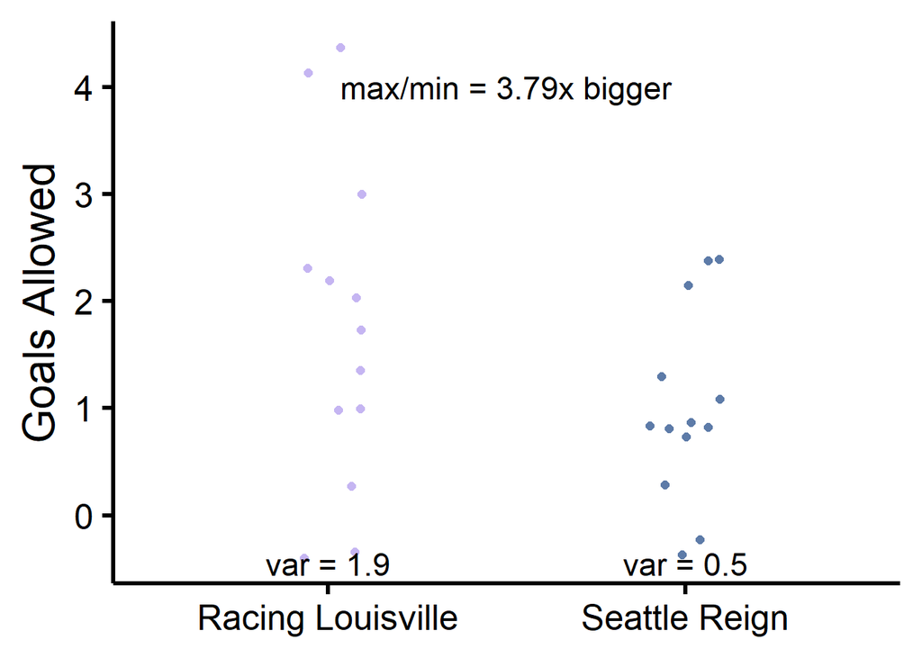

Louisville has a lot more variance.

| F statistic | p-value | method |
| --- | --- | --- |
| 3.794872 | 0.9856527 | F test to compare two variances |

Yeah. **Racing Louisville has more variance in goals allowed than Seattle this season**. How do we interpret this though? Perhaps this variance suggests that they’re conceding goals in particularly bad games rather than consistently across the board, which would definitely be a good thing.

*Hypothesis test 3: xG for*

Null hypothesis: There is no difference in the variance between Louisville’s xG generated this season and Seattle’s xG generated this season.

Alternative hypothesis: There is less variance in Louisville’s xG generated this season than Seattle’s.

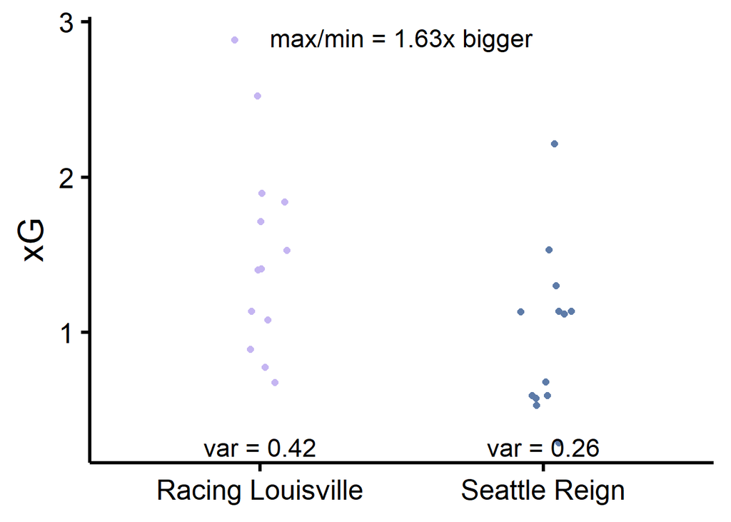

Louisville again has more variance.

| F statistic | p-value | method |
| --- | --- | --- |
| 1.625616 | 0.7939871 | F test to compare two variances |

As a reminder, Louisville has generated more xG than Seattle this season, and statistically significantly so. With that in mind, this test makes it seem like Louisville is generating its xG in spurts rather than consistently, at least when compared to a peer.

*Hypothesis test 4: xG against*

Null hypothesis: There is no difference in the variance between Louisville’s xG conceded this season and Seattle’s xG conceded this season.

Alternative hypothesis: There is less variance in Louisville’s xG conceded this season than Seattle’s.

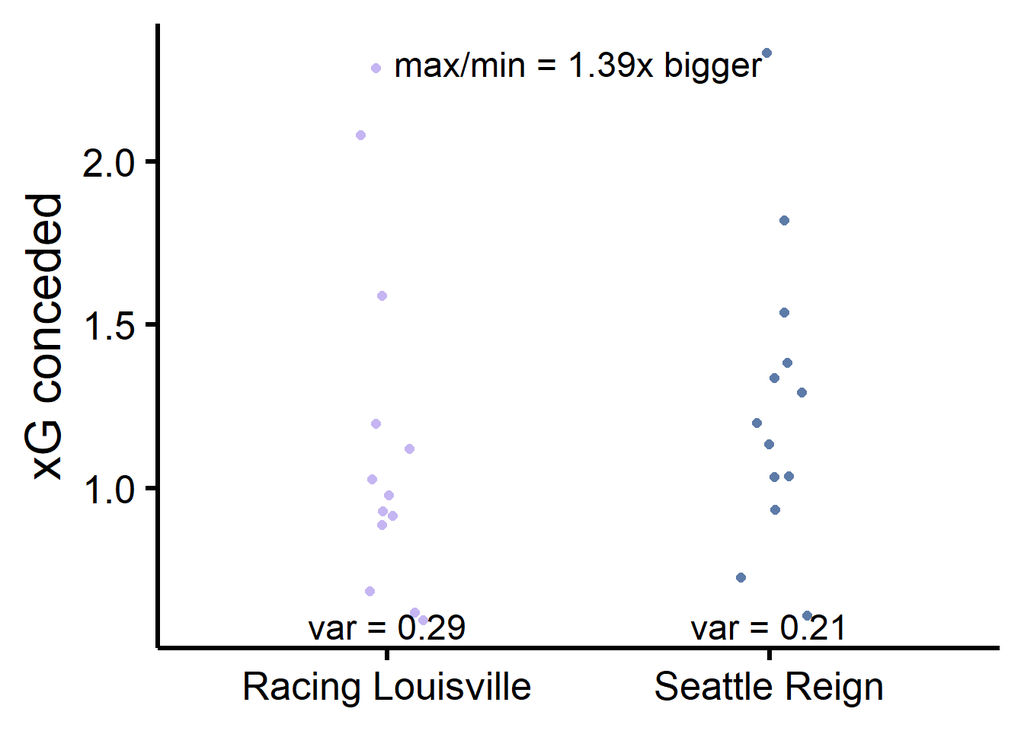

Again, Louisville has more variance but just barely.

| F statistic | p-value | method |
| --- | --- | --- |
| 1.39407 | 0.7130526 | F test to compare two variances |

As a reminder, Louisville has conceded less xG than Seattle this season, but not statistically significantly so. Their variance is slightly higher than Seattle’s, but only very slightly, so I wouldn’t read too much into it.

*Hypothesis test 5: xG differential*

Null hypothesis: There is no difference in the variance between Louisville’s xG differential this season and Seattle’s xG differential this season.

Alternative hypothesis: There is less variance in Louisville’s xG differential this season than Seattle’s.

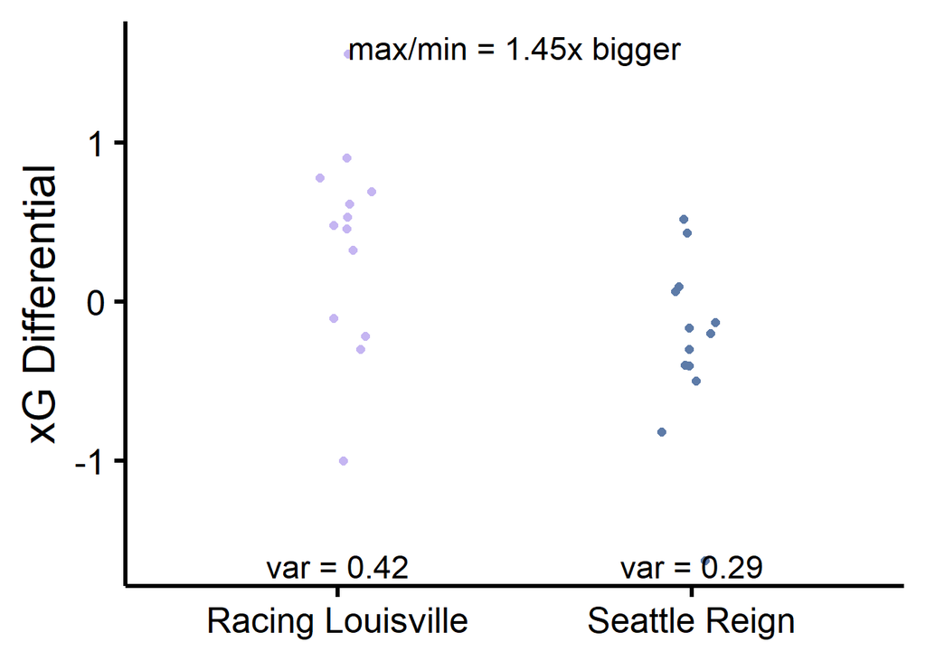

| F statistic | p-value | method |
| --- | --- | --- |
| 1.451741 | 0.7358396 | F test to compare two variances |

Seattle’s xG differential is more consistent than Louisville’s, but not by much. Not much to read into here.

*Hypothesis test 6: Shots for*

Null hypothesis: There is no difference in the variance between Louisville’s shots this season and Seattle’s shots this season.

Alternative hypothesis: There is less variance in Louisville’s shots this season than Seattle’s.

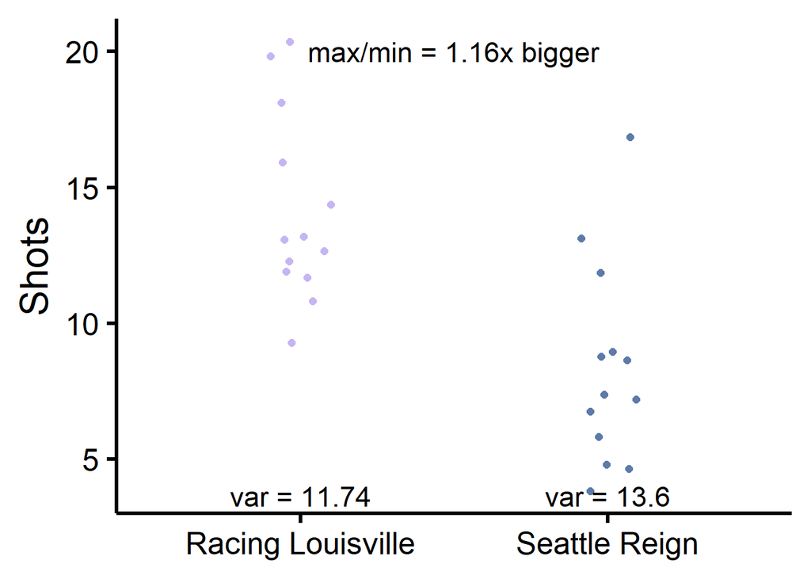

Finally, Louisville has less variance than Seattle!

| F statistic | p-value | method |
| --- | --- | --- |
| 0.8633365 | 0.4016128 | F test to compare two variances |

As a reminder, the t-test concluded that Louisville is taking statistically significantly more shots than Seattle. Here, it’s not super conclusive though, which makes me think that Louisville isn’t as consistent as they’d like to be in this metric.

*Hypothesis test 7: Shots against*

Null hypothesis: There is no difference in the variance between Louisville’s shots conceded this season and Seattle’s shots conceded this season.

Alternative hypothesis: There is less variance in Louisville’s shots conceded this season than Seattle’s.

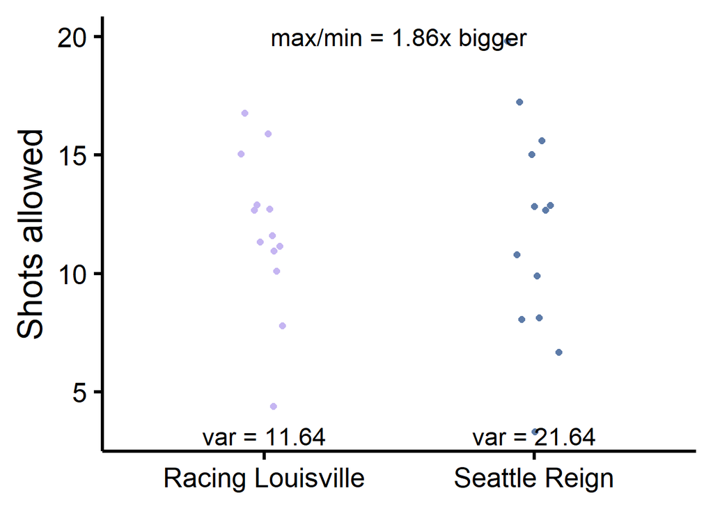

Louisville has a lot less variance here.

| F statistic | p-value | method |
| --- | --- | --- |
| 0.5379147 | 0.1482936 | F test to compare two variances |

As a reminder, Louisville and Seattle faced the same number of shots this season. Louisville having less variance suggests that they’re constantly allowing shots, where Seattle might be having individual bad games. Hard to tell what to make of this.

**Conclusion**

So, on the whole, Louisville is doing better offensively than the Reign (a team above them in standings currently) and a little worse defensively, but it seems like those defensive performances are individual lapses rather than consistently poor performances. And when compared to last season, they seem to actually be doing better. So Racing Louisville might actually be for real. But again, this has literally never happened before so we’ll have to see if it holds come November.

[Back to home](https://ajsportstat.github.io/nwsl-2025)